# Insufficient Response Analysis

## Initial setup

Import the eavehelpers package we have locally, plus any extra packages that we need for making plots etc.

```r
library(eavehelpers)
library(ggplot2)
library(phsstyles)
```

### Load Data

See notebook called ‘LoadData.Rmd’ for how the analysis dataframes were created:

```r
data.pc <- readRDS("/conf/EAVE/GPanalysis/data/temp/fail_to_mount_pc_Jan13_final.rds") %>% filter(stage>1)
data.bd <- readRDS("/conf/EAVE/GPanalysis/data/temp/fail_to_mount_bd_Jan13_final.rds") %>% filter(stage>1)
data.pc <- data.pc %>% mutate(insufficient_response=as.integer(IgG<200))
data.bd <- data.bd %>% mutate(insufficient_response=as.integer(IgG<5))
print (nrow(data.pc))
```

```
[1] 17651
```

```r
print (nrow(data.bd))
```

```
[1] 18229
```

```r
data.bd %>% group_by(insufficient_response) %>% summarise(n=n())
```

| insufficient_response | n |
| --- | --- |
| 0 | 14201 |
| 1 | 4026 |
| NA | 2 |

```r
output_folder <- file.path("results","2DOSE_Loose")# Sys.Date())
dir.create(output_folder, showWarnings = TRUE)
```

```
'results/2DOSE_Loose' already exists
```

## Model A

Build analysis dataframes for the two cohorts that we’ll use for model of type-A. We use the helper functions that take the input dataframes from the cohorts we build and they do some extra data cleaning and coding of variables (mostly it is just converting variables into factor variables that are convienent to use the the GAM fits to calculate ORs with)

```r
pc.modelA.df <- eavehelpers::get_modelA_df(data.pc) %>% droplevels()
bd.modelA.df <- eavehelpers::get_modelA_df(data.bd) %>% droplevels()
```

### Get variables to use in the models

Perform a check on the confounding variables we want to use for modelA… This function returns the names of the variables that pass the univariable logit glm test fit for the outcome variable

```r
pc.modelA.vars <- pc.modelA.df %>%
                  select(insufficient_response,prior_infection,
                         simd2020v2_sc_quintile,immuno,shielding,ch_resident) %>%
                  eavehelpers::get_vars_to_use(outcome_var='insufficient_response')
print (pc.modelA.vars)
```

```
[1] "prior_infection" "immuno"          "shielding"
```

Doing this for the blood donors shows how it helps to remove the usage of the ch_resident variable. Expected as we shouldn’t really be getting care-home residents that are also blood donors.

```r
bd.modelA.vars <- bd.modelA.df %>%
                  select(insufficient_response,prior_infection,
                         simd2020v2_sc_quintile,immuno,shielding,ch_resident) %>%
                  eavehelpers::get_vars_to_use(outcome_var='insufficient_response')
```

```
contrasts can be applied only to factors with 2 or more levels
```

```r
print (bd.modelA.vars)
```

```
[1] "prior_infection"        "simd2020v2_sc_quintile" "immuno"
```

### Construct formulas for the models

Build up a formula to use for the GAM fit for primary care attendees …

```r
pc.modelA.gam.formula <- paste0(
  "insufficient_response ~ ", #outcome varialbe
  " s(age,by=cat) + cat", #age is a spline stratified by cat (product-dose categories)
  #" + s(days_since_first_measurement) ", #spline of the number of days since the start of the pandemic/first-measurement
  " + s(days_since_last_vac) ", #days since the last vaccination, defined by the stage the measurement was taken at
  " + n_risk_gps ", #main exposure - number of QCOVID risk groups
  " + Sex + Q_BMI ", # confounding variables for Sex and BMI
  " + simd2020v2_sc_quintile",#force the inclusion of SIMD actually..
  " + ",paste0(pc.modelA.vars,collapse = " + ") #other confounding from variables named and checked above
  )
pc.modelA.df <- pc.modelA.df %>% select(stage,all.vars(as.formula(pc.modelA.gam.formula)))
pc.modelA.gam.formula
```

```
[1] "insufficient_response ~  s(age,by=cat) + cat + s(days_since_last_vac)  + n_risk_gps  + Sex + Q_BMI  + simd2020v2_sc_quintile + prior_infection + immuno + shielding"
```

Do the same for the blood donors cohort

```r
bd.modelA.gam.formula <- paste0(
  "insufficient_response ~ ", #outcome varialbe
  " s(age,by=cat) + cat", #age is a spline stratified by cat (product-dose categories)
  #" + s(days_since_first_measurement) ", #spline of the number of days since the start of the pandemic/first-measurement
  " + s(days_since_last_vac) ", #days since the last vaccination, defined by the stage the measurement was taken at
  " + n_risk_gps ", #main exposure - number of QCOVID risk groups
  " + Sex + Q_BMI ", # confounding variables for Sex and BMI
  " + simd2020v2_sc_quintile",#force the inclusion of SIMD actually..
  " + ",paste0(bd.modelA.vars,collapse = " + ") #other confounding from variables named and checked above
  )
bd.modelA.df <- bd.modelA.df %>% select(stage,all.vars(as.formula(bd.modelA.gam.formula)))
bd.modelA.gam.formula
```

```
[1] "insufficient_response ~  s(age,by=cat) + cat + s(days_since_last_vac)  + n_risk_gps  + Sex + Q_BMI  + simd2020v2_sc_quintile + prior_infection + simd2020v2_sc_quintile + immuno"
```

### Multivariable GAM construction

Perform the fit of the data to the GAM formula that we have constructed and print this out..

```r
pc.modelA.gamFit <- eavehelpers::perform_gam(pc.modelA.df,as.formula(pc.modelA.gam.formula))
summary(pc.modelA.gamFit)
```

```
Family: binomial
Link function: logit

Formula:
insufficient_response ~ s(age, by = cat) + cat + s(days_since_last_vac) +
    n_risk_gps + Sex + Q_BMI + simd2020v2_sc_quintile + prior_infection +
    immuno + shielding

Parametric coefficients:
                                   Estimate Std. Error z value Pr(>|z|)
(Intercept)                      -2.4675332  0.0984342 -25.068  < 2e-16 ***
catTwo doses of AZ                2.6022857  0.0633673  41.067  < 2e-16 ***
catMixed 3+ doses (including AZ) -1.2546069  0.1797365  -6.980 2.95e-12 ***
catMixed 3+ doses (no AZ)        -1.8427232  0.2013490  -9.152  < 2e-16 ***
n_risk_gps1                       0.0002588  0.0593603   0.004  0.99652
n_risk_gps2                       0.0303338  0.0744371   0.408  0.68363
n_risk_gps3-4                     0.1837273  0.0884437   2.077  0.03777 *
n_risk_gps5+                      0.4984303  0.1612267   3.091  0.00199 **
SexM                              0.0682684  0.0467947   1.459  0.14460
Q_BMIUnknown                     -0.0591519  0.0753414  -0.785  0.43238
Q_BMI<18.5                       -0.2751468  0.2191862  -1.255  0.20937
Q_BMI25-30                       -0.0145838  0.0777496  -0.188  0.85121
Q_BMI30+                          0.1273125  0.0753599   1.689  0.09114 .
simd2020v2_sc_quintile1          -0.1163593  0.0736488  -1.580  0.11412
simd2020v2_sc_quintile2          -0.0585069  0.0728870  -0.803  0.42214
simd2020v2_sc_quintile4           0.0146172  0.0707592   0.207  0.83634
simd2020v2_sc_quintile5          -0.0634375  0.0771386  -0.822  0.41086
simd2020v2_sc_quintileUnknown    -0.4806826  0.3074119  -1.564  0.11790
prior_infectionYes               -2.7167198  0.1492063 -18.208  < 2e-16 ***
immunoYes                         0.1258370  0.0879375   1.431  0.15244
immunoSeverely                    0.4965401  0.1003553   4.948 7.50e-07 ***
shieldingYes                      0.3242458  0.0827753   3.917 8.96e-05 ***
---
Signif. codes:  0 ‘***’ 0.001 ‘**’ 0.01 ‘*’ 0.05 ‘.’ 0.1 ‘ ’ 1

Approximate significance of smooth terms:
                                          edf Ref.df  Chi.sq  p-value
s(age):catTwo doses of Pfizer/Moderna   4.540  5.565 193.973  < 2e-16 ***
s(age):catTwo doses of AZ               4.113  5.056  39.037 2.57e-07 ***
s(age):catMixed 3+ doses (including AZ) 1.421  1.741  21.111  0.00127 **
s(age):catMixed 3+ doses (no AZ)        1.001  1.003   0.847  0.35784
s(days_since_last_vac)                  8.226  8.732 569.625  < 2e-16 ***
---
Signif. codes:  0 ‘***’ 0.001 ‘**’ 0.01 ‘*’ 0.05 ‘.’ 0.1 ‘ ’ 1

R-sq.(adj) =  0.411   Deviance explained = 39.2%
UBRE = -0.33661  Scale est. = 1         n = 17651
```

### Univariate GAM construction

Use a helper function to perform the fit the data as a univariate gam (each variable individually). From these GAM objects (one per variable in the formula) we can use them to calculate unadjusted ORs

```r
attr(pc.modelA.gamFit,'unadjusted') <- eavehelpers::calculate_unadjusted_gam(pc.modelA.df,
                                                                              as.formula(pc.modelA.gam.formula))
labels(attributes(pc.modelA.gamFit)$unadjusted)
```

```
 [1] "s(age, by = cat)"       "cat"                    "s(days_since_last_vac)" "n_risk_gps"             "Sex"
 [6] "Q_BMI"                  "simd2020v2_sc_quintile" "prior_infection"        "immuno"                 "shielding"
```

Do the same for the blood donors…

```r
bd.modelA.gamFit <- eavehelpers::perform_gam(bd.modelA.df,as.formula(bd.modelA.gam.formula))
summary(bd.modelA.gamFit)
```

```
Family: binomial
Link function: logit

Formula:
insufficient_response ~ s(age, by = cat) + cat + s(days_since_last_vac) +
    n_risk_gps + Sex + Q_BMI + simd2020v2_sc_quintile + prior_infection +
    simd2020v2_sc_quintile + immuno

Parametric coefficients:
                                  Estimate Std. Error z value Pr(>|z|)
(Intercept)                      -2.443420   0.097739 -24.999  < 2e-16 ***
catTwo doses of AZ                2.883618   0.065192  44.233  < 2e-16 ***
catMixed 3+ doses (including AZ) -1.025937   0.156301  -6.564 5.24e-11 ***
catMixed 3+ doses (no AZ)        -1.994447   0.222704  -8.956  < 2e-16 ***
n_risk_gps1                       0.083354   0.061986   1.345   0.1787
n_risk_gps2                       0.122642   0.143902   0.852   0.3941
n_risk_gps3-4                     0.283486   0.435165   0.651   0.5148
SexM                             -0.073969   0.050244  -1.472   0.1410
Q_BMIUnknown                      0.106585   0.077038   1.384   0.1665
Q_BMI<18.5                        0.352501   0.448565   0.786   0.4320
Q_BMI25-30                        0.121725   0.084051   1.448   0.1476
Q_BMI30+                          0.143466   0.088037   1.630   0.1032
simd2020v2_sc_quintile1          -0.198353   0.098548  -2.013   0.0441 *
simd2020v2_sc_quintile2           0.009072   0.083851   0.108   0.9138
simd2020v2_sc_quintile4          -0.150148   0.073040  -2.056   0.0398 *
simd2020v2_sc_quintile5          -0.085057   0.071071  -1.197   0.2314
simd2020v2_sc_quintileUnknown    -0.783335   0.396225  -1.977   0.0480 *
prior_infectionYes               -3.306682   0.164419 -20.111  < 2e-16 ***
immunoYes                         0.766573   0.413928   1.852   0.0640 .
immunoSeverely                    1.586254   0.704955   2.250   0.0244 *
---
Signif. codes:  0 ‘***’ 0.001 ‘**’ 0.01 ‘*’ 0.05 ‘.’ 0.1 ‘ ’ 1

Approximate significance of smooth terms:
                                          edf Ref.df  Chi.sq p-value
s(age):catTwo doses of Pfizer/Moderna   1.941  2.439 184.550 < 2e-16 ***
s(age):catTwo doses of AZ               4.246  5.204  18.862 0.00239 **
s(age):catMixed 3+ doses (including AZ) 1.023  1.046   1.684 0.19356
s(age):catMixed 3+ doses (no AZ)        6.174  7.204  14.826 0.04693 *
s(days_since_last_vac)                  8.616  8.928 809.161 < 2e-16 ***
---
Signif. codes:  0 ‘***’ 0.001 ‘**’ 0.01 ‘*’ 0.05 ‘.’ 0.1 ‘ ’ 1

R-sq.(adj) =  0.449   Deviance explained = 43.7%
UBRE = -0.40042  Scale est. = 1         n = 18227
```

Get the univariable (unadjusted) fits for the blood donors

```r
attr(bd.modelA.gamFit,'unadjusted') <- eavehelpers::calculate_unadjusted_gam(bd.modelA.df,
                                                                              as.formula(bd.modelA.gam.formula))
```

```
Fitting terminated with step failure - check results carefully
```

```r
labels(attributes(bd.modelA.gamFit)$unadjusted)
```

```
[1] "s(age, by = cat)"       "cat"                    "s(days_since_last_vac)" "n_risk_gps"             "Sex"
[6] "Q_BMI"                  "simd2020v2_sc_quintile" "prior_infection"        "immuno"
```

### Save the fitted models

Make a temporary save of the GAM objects incase we ever need to open them for future comparisons/checks.

```r
saveRDS(pc.modelA.gamFit,paste0(output_folder,'/modelA_pc_gamFit.rds'))
saveRDS(bd.modelA.gamFit,paste0(output_folder,'/modelA_bd_gamFit.rds'))
```

### ORs (linear variables)

Extract the Odds Ratios (ORs) for the parametric variables (linear variables) used from the GAM. Print out the odds ratio and the unadjusted odds ratio

```r
pc.modelA.gamFit.or <- eavehelpers::get_or_from_gam(pc.modelA.gamFit)
pc.modelA.gamFit.or %>% select(label,level,OR,uOR)
```

| label | level | OR | uOR |
| --- | --- | --- | --- |
| Vaccine Dose | Two doses of Pfizer/Moderna (ref) | 1.00000000 | NA |
| Vaccine Dose | Two doses of AZ | 13.49454792 | 12.96441206 |
| Vaccine Dose | Mixed 3+ doses (including AZ) | 0.28518794 | 0.38330417 |
| Vaccine Dose | Mixed 3+ doses (no AZ) | 0.15838552 | 0.13956743 |
| Immunosuppressed | No (ref) | 1.00000000 | NA |
| Immunosuppressed | Yes | 1.13409728 | 1.27194459 |
| Immunosuppressed | Severely | 1.64302670 | 1.81905759 |
| Number of Risks | 0 (ref) | 1.00000000 | NA |
| Number of Risks | 1 | 1.00025886 | 1.33790772 |
| Number of Risks | 2 | 1.03079852 | 1.70119246 |

[output cut: 19 more lines]

```r
bd.modelA.gamFit.or <- eavehelpers::get_or_from_gam(bd.modelA.gamFit) %>% filter(is.finite(UCL))
bd.modelA.gamFit.or %>% select(level,OR,uOR)
```

| level | OR | uOR |
| --- | --- | --- |
| Two doses of Pfizer/Moderna (ref) | 1.00000000 | NA |
| Two doses of AZ | 17.87883848 | 13.09371930 |
| Mixed 3+ doses (including AZ) | 0.35846031 | 0.24487251 |
| Mixed 3+ doses (no AZ) | 0.13608889 | 0.13068912 |
| No (ref) | 1.00000000 | NA |
| Yes | 2.15237645 | 2.25425888 |
| Severely | 4.88541557 | 3.14880605 |
| 0 (ref) | 1.00000000 | NA |
| 1 | 1.08692694 | 1.07139439 |
| 2 | 1.13047983 | 1.08790573 |

[output cut: 16 more lines]

```
Ignoring unknown parameters: width
```

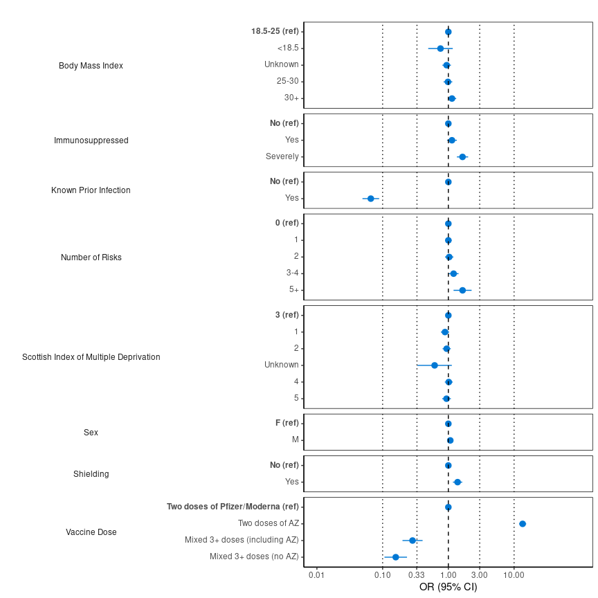

```r
eavehelpers::plot_ratios(pc.modelA.gamFit.or %>% rename(Nominal=OR))
```

```
Ignoring unknown parameters: width
```

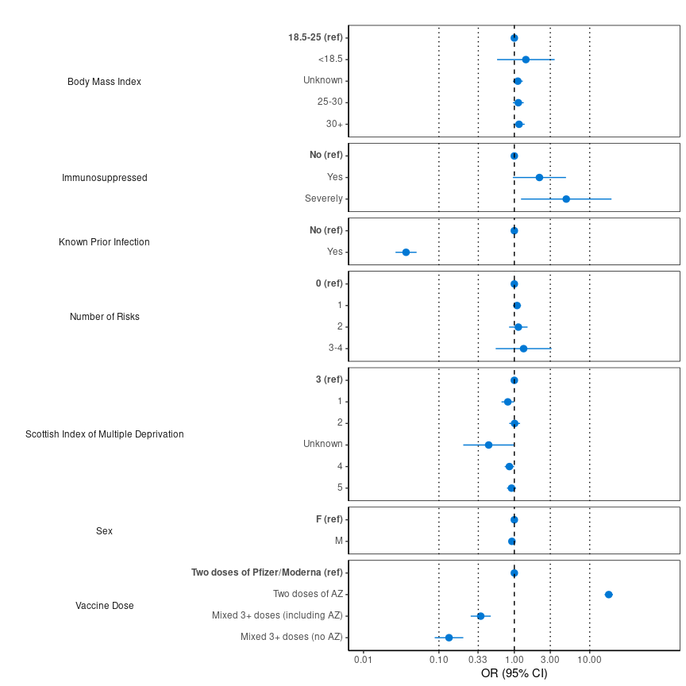

```r
eavehelpers::plot_ratios(bd.modelA.gamFit.or %>% rename(Nominal=OR))
```

```r
modelA.gamFit.or <- pc.modelA.gamFit.or %>% mutate(cohort='Primary Care') %>% rbind(bd.modelA.gamFit.or %>% mutate(cohort='Blood Donors') ) %>% rename(Nominal=OR)
saveRDS(modelA.gamFit.or,paste0(output_folder,'/modelA_gamFit_OR.rds'))
eavehelpers::display_ratios_table(modelA.gamFit.or)
```

| label | level | Ratio |
| --- | --- | --- |
| Vaccine Dose | <b>Two doses of Pfizer/Moderna (ref)</b> | - |
|  | Two doses of AZ | 13.49 (11.92 - 15.28 ) |
|  | Mixed 3+ doses (including AZ) | 0.29 (0.2 - 0.41 ) |
|  | Mixed 3+ doses (no AZ) | 0.16 (0.11 - 0.24 ) |
| Immunosuppressed | <b>No (ref)</b> | - |
|  | Yes | 1.13 (0.95 - 1.35 ) |
|  | Severely | 1.64 (1.35 - 2 ) |
| Number of Risks | <b>0 (ref)</b> | - |
|  | 1 | 1 (0.89 - 1.12 ) |
|  | 2 | 1.03 (0.89 - 1.19 ) |
|  | 3-4 | 1.2 (1.01 - 1.43 ) |
|  | 5+ | 1.65 (1.2 - 2.26 ) |
| Known Prior Infection | <b>No (ref)</b> | - |
|  | Yes | 0.07 (0.05 - 0.09 ) |
| Body Mass Index | <b>18.5-25 (ref)</b> | - |
|  | Unknown | 0.94 (0.81 - 1.09 ) |
|  | <18.5 | 0.76 (0.49 - 1.17 ) |
|  | 25-30 | 0.99 (0.85 - 1.15 ) |
|  | 30+ | 1.14 (0.98 - 1.32 ) |
| Sex | <b>F (ref)</b> | - |
|  | M | 1.07 (0.98 - 1.17 ) |
| Shielding | <b>No (ref)</b> | - |
|  | Yes | 1.38 (1.18 - 1.63 ) |
| Scottish Index of Multiple Deprivation | <b>3 (ref)</b> | - |
|  | 1 | 0.89 (0.77 - 1.03 ) |
|  | 2 | 0.94 (0.82 - 1.09 ) |
|  | 4 | 1.01 (0.88 - 1.17 ) |
|  | 5 | 0.94 (0.81 - 1.09 ) |
|  | Unknown | 0.62 (0.34 - 1.13 ) |
|  | <b>Two doses of Pfizer/Moderna (ref)</b> | - |
|  | Two doses of AZ | 17.88 (15.73 - 20.32 ) |
|  | Mixed 3+ doses (including AZ) | 0.36 (0.26 - 0.49 ) |
|  | Mixed 3+ doses (no AZ) | 0.14 (0.09 - 0.21 ) |
|  | <b>No (ref)</b> | - |
|  | Yes | 2.15 (0.96 - 4.84 ) |
|  | Severely | 4.89 (1.23 - 19.45 ) |
|  | <b>0 (ref)</b> | - |
|  | 1 | 1.09 (0.96 - 1.23 ) |
|  | 2 | 1.13 (0.85 - 1.5 ) |
|  | 3-4 | 1.33 (0.57 - 3.12 ) |
|  | <b>No (ref)</b> | - |
|  | Yes | 0.04 (0.03 - 0.05 ) |
|  | <b>18.5-25 (ref)</b> | - |
|  | Unknown | 1.11 (0.96 - 1.29 ) |
|  | <18.5 | 1.42 (0.59 - 3.43 ) |
|  | 25-30 | 1.13 (0.96 - 1.33 ) |
|  | 30+ | 1.15 (0.97 - 1.37 ) |
|  | <b>F (ref)</b> | - |
|  | M | 0.93 (0.84 - 1.02 ) |
|  | <b>3 (ref)</b> | - |
|  | 1 | 0.82 (0.68 - 0.99 ) |
|  | 2 | 1.01 (0.86 - 1.19 ) |
|  | 4 | 0.86 (0.75 - 0.99 ) |
|  | 5 | 0.92 (0.8 - 1.06 ) |
|  | Unknown | 0.46 (0.21 - 0.99 ) |

```r
p.modelA.gamFit.or <- eavehelpers::plot_ratios(modelA.gamFit.or,
                                               fill=cohort,
                                               facet=as.factor(label) ~ fct_rev(as.factor(cohort))
                                               )
```

```
Ignoring unknown parameters: width
```

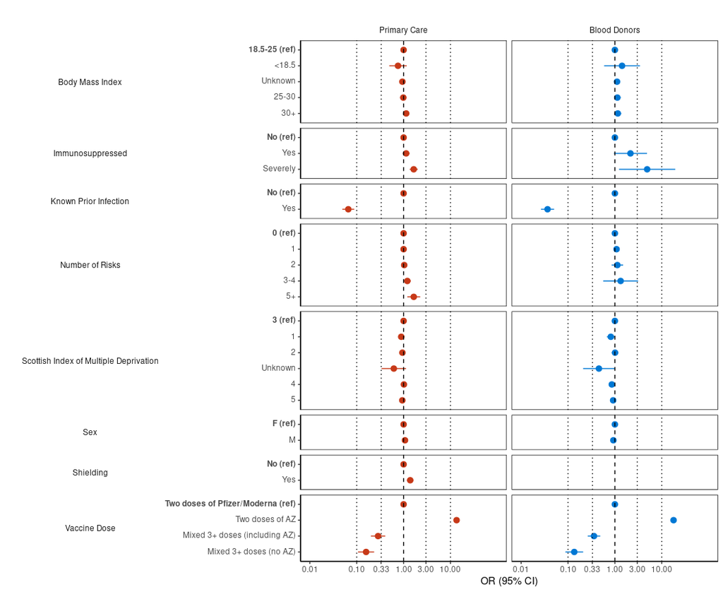

```r
p.modelA.gamFit.or
```

## Model B

Build analysis dataframes

```r
pc.modelB.df <- eavehelpers::get_modelB_df(data.pc)
bd.modelB.df <- eavehelpers::get_modelB_df(data.bd)
```

Check these variables again…

```r
pc.modelB.vars <- pc.modelB.df %>%
                  select(insufficient_response,prior_infection,
                         simd2020v2_sc_quintile,immuno,shielding,ch_resident) %>%
                  eavehelpers::get_vars_to_use(outcome_var='insufficient_response',thres=0.5)
print (pc.modelB.vars)
```

```
[1] "prior_infection"        "simd2020v2_sc_quintile" "shielding"
```

```r
bd.modelB.vars <- bd.modelB.df %>%
                  select(insufficient_response,prior_infection,
                         simd2020v2_sc_quintile,immuno,shielding,ch_resident) %>%
                  eavehelpers::get_vars_to_use(outcome_var='insufficient_response',thres=0.5)
```

```
contrasts can be applied only to factors with 2 or more levels
```

```r
print (bd.modelB.vars)
```

```
[1] "prior_infection"        "simd2020v2_sc_quintile" "immuno"                 "shielding"
```

Use the helper function to work out which QCOVID terms to include. We use ones where there are at least 5 events with the outcome of insufficient response

```r
pc.modelB.qnames <- get_qcovid_names(pc.modelB.df,n=5)
pc.modelB.qnames
```

```
 [1] "Q_DIAG_AF"            "Q_DIAG_ASTHMA"        "Q_DIAG_BLOOD_CANCER"  "Q_DIAG_CCF"           "Q_DIAG_CEREBRALPALSY"
 [6] "Q_DIAG_CHD"           "Q_DIAG_CIRRHOSIS"     "Q_DIAG_CONGEN_HD"     "Q_DIAG_COPD"          "Q_DIAG_DEMENTIA"
[11] "Q_DIAG_DIABETES_1"    "Q_DIAG_DIABETES_2"    "Q_DIAG_EPILEPSY"      "Q_DIAG_FRACTURE"      "Q_DIAG_NEURO"
[16] "Q_DIAG_PARKINSONS"    "Q_DIAG_PULM_HYPER"    "Q_DIAG_PULM_RARE"     "Q_DIAG_PVD"           "Q_DIAG_RA_SLE"
[21] "Q_DIAG_RESP_CANCER"   "Q_DIAG_SEV_MENT_ILL"  "Q_DIAG_SICKLE_CELL"   "Q_DIAG_STROKE"        "Q_DIAG_VTE"
[26] "Q_DIAG_CKD"
```

```r
bd.modelB.qnames <- get_qcovid_names(bd.modelB.df,n=5)
bd.modelB.qnames
```

```
 [1] "Q_DIAG_AF"           "Q_DIAG_ASTHMA"       "Q_DIAG_CIRRHOSIS"    "Q_DIAG_CONGEN_HD"    "Q_DIAG_COPD"         "Q_DIAG_DIABETES_2"
 [7] "Q_DIAG_EPILEPSY"     "Q_DIAG_FRACTURE"     "Q_DIAG_PULM_RARE"    "Q_DIAG_RA_SLE"       "Q_DIAG_SEV_MENT_ILL" "Q_DIAG_VTE"
[13] "Q_DIAG_CKD"
```

```r
pc.modelB.gam.formula <- paste0(
  "insufficient_response ~ ", #outcome varialbe
  " s(age,by=cat) + cat", #age is a spline stratified by cat (product-dose categories)
  #" + s(days_since_first_measurement) ", #spline of the number of days since the start of the pandemic/first-measurement
  " + s(days_since_last_vac) ", #days since the last vaccination, defined by the stage the measurement was taken at
  " + ",paste0(pc.modelB.qnames,collapse = " + "), #main exposure - the individiual qcovid risk groups
  " + Sex + Q_BMI ", # confounding variables for Sex and BMI
  " + simd2020v2_sc_quintile",#force the inclusion of SIMD actually..
  " + ",paste0(pc.modelB.vars,collapse = " + ") #other confounding from variables named and checked above
  )
#pc.modelB.df <- pc.modelB.df %>% select(stage,all.vars(as.formula(pc.modelB.gam.formula)))
pc.modelB.gam.formula
```

```
[1] "insufficient_response ~  s(age,by=cat) + cat + s(days_since_last_vac)  + Q_DIAG_AF + Q_DIAG_ASTHMA + Q_DIAG_BLOOD_CANCER + Q_DIAG_CCF + Q_DIAG_CEREBRALPALSY + Q_DIAG_CHD + Q_DIAG_CIRRHOSIS + Q_DIAG_CONGEN_HD + Q_DIAG_COPD + Q_DIAG_DEMENTIA + Q_DIAG_DIABETES_1 + Q_DIAG_DIABETES_2 + Q_DIAG_EPILEP…
```

```r
bd.modelB.gam.formula <- paste0(
  "insufficient_response ~ ", #outcome varialbe
  " s(age,by=cat,k=3) + cat", #age is a spline stratified by cat (product-dose categories)
  #" + s(days_since_first_measurement) ", #spline of the number of days since the start of the pandemic/first-measurement
  " + s(days_since_last_vac) ", #days since the last vaccination, defined by the stage the measurement was taken at
  " + ",paste0(bd.modelB.qnames,collapse = " + "), #main exposure - the individiual qcovid risk groups
  " + Sex + Q_BMI ", # confounding variables for Sex and BMI
  " + simd2020v2_sc_quintile",#force the inclusion of SIMD actually..
  " + ",paste0(bd.modelB.vars,collapse = " + ") #other confounding from variables named and checked above
  )
#bd.modelA.df <- bd.modelA.df %>% select(stage,all.vars(as.formula(bd.modelA.gam.formula)))
bd.modelB.gam.formula
```

```
[1] "insufficient_response ~  s(age,by=cat,k=3) + cat + s(days_since_last_vac)  + Q_DIAG_AF + Q_DIAG_ASTHMA + Q_DIAG_CIRRHOSIS + Q_DIAG_CONGEN_HD + Q_DIAG_COPD + Q_DIAG_DIABETES_2 + Q_DIAG_EPILEPSY + Q_DIAG_FRACTURE + Q_DIAG_PULM_RARE + Q_DIAG_RA_SLE + Q_DIAG_SEV_MENT_ILL + Q_DIAG_VTE + Q_DIAG_CKD +…
```

```r
pc.modelB.gamFit <- eavehelpers::perform_gam(pc.modelB.df,as.formula(pc.modelB.gam.formula))
summary(pc.modelB.gamFit)
```

```
Family: binomial
Link function: logit

Formula:
insufficient_response ~ s(age, by = cat) + cat + s(days_since_last_vac) +
    Q_DIAG_AF + Q_DIAG_ASTHMA + Q_DIAG_BLOOD_CANCER + Q_DIAG_CCF +
    Q_DIAG_CEREBRALPALSY + Q_DIAG_CHD + Q_DIAG_CIRRHOSIS + Q_DIAG_CONGEN_HD +
    Q_DIAG_COPD + Q_DIAG_DEMENTIA + Q_DIAG_DIABETES_1 + Q_DIAG_DIABETES_2 +
    Q_DIAG_EPILEPSY + Q_DIAG_FRACTURE + Q_DIAG_NEURO + Q_DIAG_PARKINSONS +
    Q_DIAG_PULM_HYPER + Q_DIAG_PULM_RARE + Q_DIAG_PVD + Q_DIAG_RA_SLE +
    Q_DIAG_RESP_CANCER + Q_DIAG_SEV_MENT_ILL + Q_DIAG_SICKLE_CELL +
    Q_DIAG_STROKE + Q_DIAG_VTE + Q_DIAG_CKD + Sex + Q_BMI + simd2020v2_sc_quintile +
    prior_infection + simd2020v2_sc_quintile + shielding

Parametric coefficients:
                                  Estimate Std. Error z value Pr(>|z|)
(Intercept)                      -2.222974   0.132649 -16.758  < 2e-16 ***
catTwo doses of AZ                2.311000   0.083290  27.747  < 2e-16 ***
catMixed 3+ doses (including AZ) -1.293324   0.183593  -7.045 1.86e-12 ***
catMixed 3+ doses (no AZ)        -1.813804   0.239694  -7.567 3.81e-14 ***
Q_DIAG_AFYes                     -0.171702   0.110857  -1.549  0.12142
Q_DIAG_ASTHMAYes                  0.077346   0.076794   1.007  0.31385
Q_DIAG_BLOOD_CANCERYes            0.608585   0.228498   2.663  0.00774 **
Q_DIAG_CCFYes                     0.181170   0.145661   1.244  0.21358
Q_DIAG_CEREBRALPALSYYes           0.609165   0.588320   1.035  0.30047
Q_DIAG_CHDYes                     0.032750   0.090230   0.363  0.71664
Q_DIAG_CIRRHOSISYes               0.446141   0.210970   2.115  0.03445 *
Q_DIAG_CONGEN_HDYes              -0.228236   0.185338  -1.231  0.21815
Q_DIAG_COPDYes                   -0.001187   0.114313  -0.010  0.99171
Q_DIAG_DEMENTIAYes                0.104669   0.235162   0.445  0.65625
Q_DIAG_DIABETES_1Yes              0.048079   0.228743   0.210  0.83352
Q_DIAG_DIABETES_2Yes              0.227726   0.076718   2.968  0.00299 **
Q_DIAG_EPILEPSYYes               -0.128166   0.176355  -0.727  0.46738
Q_DIAG_FRACTUREYes               -0.010253   0.106927  -0.096  0.92361
Q_DIAG_NEUROYes                   0.139762   0.292070   0.479  0.63228
Q_DIAG_PARKINSONSYes              0.821069   0.425914   1.928  0.05388 .
Q_DIAG_PULM_HYPERYes              0.358754   0.315583   1.137  0.25562
Q_DIAG_PULM_RAREYes               0.082363   0.235486   0.350  0.72652
Q_DIAG_PVDYes                     0.119311   0.169732   0.703  0.48210
Q_DIAG_RA_SLEYes                  0.236719   0.127223   1.861  0.06279 .
```

[output cut: 18 more lines]

```
---
Signif. codes:  0 ‘***’ 0.001 ‘**’ 0.01 ‘*’ 0.05 ‘.’ 0.1 ‘ ’ 1

Approximate significance of smooth terms:
                                          edf Ref.df  Chi.sq  p-value
s(age):catTwo doses of Pfizer/Moderna   4.630  5.660  73.465 1.35e-13 ***
s(age):catTwo doses of AZ               2.396  3.033  12.964  0.00487 **
s(age):catMixed 3+ doses (including AZ) 1.001  1.002   9.224  0.00239 **
s(age):catMixed 3+ doses (no AZ)        1.000  1.001   0.035  0.85243
s(days_since_last_vac)                  8.277  8.790 276.572  < 2e-16 ***
---
Signif. codes:  0 ‘***’ 0.001 ‘**’ 0.01 ‘*’ 0.05 ‘.’ 0.1 ‘ ’ 1

R-sq.(adj) =   0.39   Deviance explained =   36%
UBRE = -0.2344  Scale est. = 1         n = 8723
```

```r
attr(pc.modelB.gamFit,'unadjusted') <- eavehelpers::calculate_unadjusted_gam(pc.modelB.df,
                                                                              as.formula(pc.modelB.gam.formula))
labels(attributes(pc.modelB.gamFit)$unadjusted)
```

```
 [1] "s(age, by = cat)"       "cat"                    "s(days_since_last_vac)" "Q_DIAG_AF"              "Q_DIAG_ASTHMA"
 [6] "Q_DIAG_BLOOD_CANCER"    "Q_DIAG_CCF"             "Q_DIAG_CEREBRALPALSY"   "Q_DIAG_CHD"             "Q_DIAG_CIRRHOSIS"
[11] "Q_DIAG_CONGEN_HD"       "Q_DIAG_COPD"            "Q_DIAG_DEMENTIA"        "Q_DIAG_DIABETES_1"      "Q_DIAG_DIABETES_2"
[16] "Q_DIAG_EPILEPSY"        "Q_DIAG_FRACTURE"        "Q_DIAG_NEURO"           "Q_DIAG_PARKINSONS"      "Q_DIAG_PULM_HYPER"
[21] "Q_DIAG_PULM_RARE"       "Q_DIAG_PVD"             "Q_DIAG_RA_SLE"          "Q_DIAG_RESP_CANCER"     "Q_DIAG_SEV_MENT_ILL"
[26] "Q_DIAG_SICKLE_CELL"     "Q_DIAG_STROKE"          "Q_DIAG_VTE"             "Q_DIAG_CKD"             "Sex"
[31] "Q_BMI"                  "simd2020v2_sc_quintile" "prior_infection"        "shielding"
```

```r
bd.modelB.gamFit <- eavehelpers::perform_gam(bd.modelB.df,as.formula(bd.modelB.gam.formula))
summary(bd.modelB.gamFit)
```

```
Family: binomial
Link function: logit

Formula:
insufficient_response ~ s(age, by = cat, k = 3) + cat + s(days_since_last_vac) +
    Q_DIAG_AF + Q_DIAG_ASTHMA + Q_DIAG_CIRRHOSIS + Q_DIAG_CONGEN_HD +
    Q_DIAG_COPD + Q_DIAG_DIABETES_2 + Q_DIAG_EPILEPSY + Q_DIAG_FRACTURE +
    Q_DIAG_PULM_RARE + Q_DIAG_RA_SLE + Q_DIAG_SEV_MENT_ILL +
    Q_DIAG_VTE + Q_DIAG_CKD + Sex + Q_BMI + simd2020v2_sc_quintile +
    prior_infection + simd2020v2_sc_quintile + immuno + shielding

Parametric coefficients:
                                 Estimate Std. Error z value Pr(>|z|)
(Intercept)                      -2.38462    0.22975 -10.379  < 2e-16 ***
catTwo doses of AZ                2.80982    0.12328  22.793  < 2e-16 ***
catMixed 3+ doses (including AZ) -1.09670    0.28529  -3.844 0.000121 ***
catMixed 3+ doses (no AZ)        -1.57308    0.29177  -5.392 6.99e-08 ***
Q_DIAG_AFYes                      0.89702    0.62911   1.426 0.153908
Q_DIAG_ASTHMAYes                 -0.03819    0.14785  -0.258 0.796158
Q_DIAG_CIRRHOSISYes              -0.49355    0.28995  -1.702 0.088724 .
Q_DIAG_CONGEN_HDYes              -0.20163    0.49128  -0.410 0.681496
Q_DIAG_COPDYes                    0.33957    0.41875   0.811 0.417412
Q_DIAG_DIABETES_2Yes              0.48402    0.22118   2.188 0.028642 *
Q_DIAG_EPILEPSYYes                0.20310    0.40502   0.501 0.616046
Q_DIAG_FRACTUREYes               -0.05366    0.17990  -0.298 0.765475
Q_DIAG_PULM_RAREYes               0.28610    0.55078   0.519 0.603453
Q_DIAG_RA_SLEYes                 -0.41196    0.57220  -0.720 0.471546
Q_DIAG_SEV_MENT_ILLYes            0.05611    0.14700   0.382 0.702650
Q_DIAG_VTEYes                     0.31624    0.30782   1.027 0.304264
Q_DIAG_CKDYes                     0.15560    0.38445   0.405 0.685678
SexM                             -0.03392    0.10465  -0.324 0.745814
Q_BMIUnknown                      0.25123    0.16053   1.565 0.117585
Q_BMI<18.5                        1.48446    0.67743   2.191 0.028429 *
Q_BMI25-30                        0.07074    0.14948   0.473 0.636031
Q_BMI30+                          0.07414    0.15140   0.490 0.624356
simd2020v2_sc_quintile1          -0.18098    0.18896  -0.958 0.338181
simd2020v2_sc_quintile2           0.14516    0.16837   0.862 0.388596
simd2020v2_sc_quintile4          -0.24187    0.14951  -1.618 0.105729
simd2020v2_sc_quintile5          -0.06408    0.14756  -0.434 0.664109
simd2020v2_sc_quintileUnknown     0.40814    0.71759   0.569 0.569515
prior_infectionYes               -3.31658    0.30058 -11.034  < 2e-16 ***
immunoYes                         1.78902    0.73953   2.419 0.015558 *
immunoSeverely                    1.23924    0.95067   1.304 0.192391
shieldingYes                      0.30163    0.49300   0.612 0.540657
---
Signif. codes:  0 ‘***’ 0.001 ‘**’ 0.01 ‘*’ 0.05 ‘.’ 0.1 ‘ ’ 1

Approximate significance of smooth terms:
                                          edf Ref.df  Chi.sq  p-value
s(age):catTwo doses of Pfizer/Moderna   1.001  1.001  40.960 1.57e-10 ***
s(age):catTwo doses of AZ               1.001  1.001   0.345    0.557
s(age):catMixed 3+ doses (including AZ) 1.000  1.001   0.228    0.633
s(age):catMixed 3+ doses (no AZ)        1.607  1.846   1.402    0.488
s(days_since_last_vac)                  6.961  7.844 234.132  < 2e-16 ***
---
Signif. codes:  0 ‘***’ 0.001 ‘**’ 0.01 ‘*’ 0.05 ‘.’ 0.1 ‘ ’ 1

R-sq.(adj) =  0.451   Deviance explained =   44%
UBRE = -0.37633  Scale est. = 1         n = 4418
```

```r
attr(bd.modelB.gamFit,'unadjusted') <- eavehelpers::calculate_unadjusted_gam(bd.modelB.df,
                                                                              as.formula(bd.modelB.gam.formula))
labels(attributes(bd.modelB.gamFit)$unadjusted)
```

```
 [1] "s(age, by = cat, k = 3)" "cat"                     "s(days_since_last_vac)"  "Q_DIAG_AF"               "Q_DIAG_ASTHMA"
 [6] "Q_DIAG_CIRRHOSIS"        "Q_DIAG_CONGEN_HD"        "Q_DIAG_COPD"             "Q_DIAG_DIABETES_2"       "Q_DIAG_EPILEPSY"
[11] "Q_DIAG_FRACTURE"         "Q_DIAG_PULM_RARE"        "Q_DIAG_RA_SLE"           "Q_DIAG_SEV_MENT_ILL"     "Q_DIAG_VTE"
[16] "Q_DIAG_CKD"              "Sex"                     "Q_BMI"                   "simd2020v2_sc_quintile"  "prior_infection"
[21] "immuno"                  "shielding"
```